# Analysis of the mtcars Dataset

30/04/2021

## The goal of our analysis

The relationship between miles per gallon (MPG) and the other variables of the dataset. We have a data set of a collection of cars, and we are interested in exploring the relationship between a set of variables and miles per gallon (MPG). The App user can choose the variable which he wants to compare, and we display a plot of a boxplot and the linear regression analysis. The user can choose too if the outliers appear or not.

The *mtcars* Dataset was extracted from the 1974 Motor Trend US magazine,and comprises fuel consumption and 10 aspects of automobile design and performance for 32 automobiles (1973-74 models)

## The Dataset Format

We work with a data frame with 32 observations on 11 (numeric) variables.

Let’s look the first rows:

```r
library(datasets)
head(mtcars)
```

```
                   mpg cyl disp  hp drat    wt  qsec vs am gear carb
Mazda RX4         21.0   6  160 110 3.90 2.620 16.46  0  1    4    4
Mazda RX4 Wag     21.0   6  160 110 3.90 2.875 17.02  0  1    4    4
Datsun 710        22.8   4  108  93 3.85 2.320 18.61  1  1    4    1
Hornet 4 Drive    21.4   6  258 110 3.08 3.215 19.44  1  0    3    1
Hornet Sportabout 18.7   8  360 175 3.15 3.440 17.02  0  0    3    2
Valiant           18.1   6  225 105 2.76 3.460 20.22  1  0    3    1
```

## The *MPG* variable

Due to our analysis is centered on the relationship between miles per gallon (MPG) and the other variables, let’s look at our main variable:

```r
summary(mtcars$mpg)
```

```
   Min. 1st Qu.  Median    Mean 3rd Qu.    Max.
  10.40   15.43   19.20   20.09   22.80   33.90
```

## The *MPG* variable

We can see the distribution’s shape of the variable if we plot its histogram.

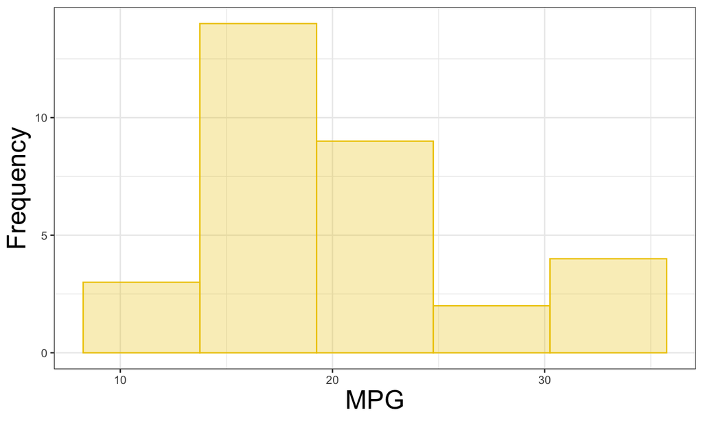